# Data Analysis data.table way

22/10/2018

Notes from the DataCamp course conducted by the authors of the data.table package - Matt Dowle and Arun Srinivasan

Just like other DataCamp courses, this course provides a quick and brief overview of the data.table package. It will not make you an expert in data.table but covers the basic concepts. These concepts when applied to real-life project will make you an expert.

The course has three chapters - Novice, Yeoman and Expert. This post has my notes from all of them. It also has notes from some side-reading I did while doing the course

**Chapter 1 : data.table novice**

The data.table has three key elements DT[i,j,by]

- i : Filtering the rows (SQL WHERE)
- j : Choosing the columns (SQL SELECT)
- by : For grouping (SQL GROUP BY)

Create a data.table using recycling

```r
DT <- data.table(a = c(1L,2L), b = LETTERS[1:4], c = 1)
DT
```

```
##    a b c
## 1: 1 A 1
## 2: 2 B 1
## 3: 1 C 1
## 4: 2 D 1
```

### Selecting columns in j

- .() is an alias to list() in data.tables
- Without .(), it will return a vector
- When you use .() in j, the result is always a data.table. For convenience, data.table also provides the option to return a vector while computing on just a single column and not wrapping it with .().
- j can be used to select columns by wrapping the column names in .().
- **The column names within DT[…] are treated as variables**

```r
DT <- data.table(A=c(1:5L),
                 B=c("a","b"),
                 C=c(6:10))
#Gives a vector
DT[,B]
```

```
## [1] "a" "b" "a" "b" "a"
```

```r
DT[,c(B,C)]
```

```
##  [1] "a"  "b"  "a"  "b"  "a"  "6"  "7"  "8"  "9"  "10"
```

```r
#gives a data.table, traditional DF way
DT[,"B"]
```

```
##    B
## 1: a
## 2: b
## 3: a
## 4: b
## 5: a
```

```r
DT[,c("B","C")]
```

```
##    B  C
## 1: a  6
## 2: b  7
## 3: a  8
## 4: b  9
## 5: a 10
```

```r
#Data.table way
DT[,2] #bad practice to refer columns by their numbers
```

```
##    B
## 1: a
## 2: b
## 3: a
## 4: b
## 5: a
```

```r
DT[,.(B,C)]
```

```
##    B  C
## 1: a  6
## 2: b  7
## 3: a  8
## 4: b  9
## 5: a 10
```

```r
DT[,list(B,C)]
```

```
##    B  C
## 1: a  6
## 2: b  7
## 3: a  8
## 4: b  9
## 5: a 10
```

```r
#Using column names as variables
DT[,A*C]
```

```
## [1]  6 14 24 36 50
```

```r
DT[,.(B,myresult = A*C)]
```

```
##    B myresult
## 1: a        6
## 2: b       14
## 3: a       24
## 4: b       36
## 5: a       50
```

### Expressions {} and Funcitons within DT

```r
#Use {} to create a variable and use it with a column
DT[,.(A,B,C,{var <- C*100; var + A})]
```

```
##    A B  C   V4
## 1: 1 a  6  601
## 2: 2 b  7  702
## 3: 3 a  8  803
## 4: 4 b  9  904
## 5: 5 a 10 1005
```

```r
#Call any function, Wrap inside .() to return DT
DT[,.(sin(A),cos(A))]
```

```
##            V1         V2
## 1:  0.8414710  0.5403023
## 2:  0.9092974 -0.4161468
## 3:  0.1411200 -0.9899925
## 4: -0.7568025 -0.6536436
## 5: -0.9589243  0.2836622
```

```
## [1] 1 2 3 4 5
```

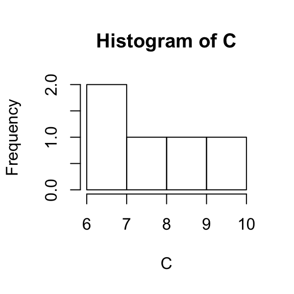

```
##    V1
## 1:  7
## 2:  9
## 3: 11
## 4: 13
## 5: 15
```

```r
#Multiple expressions can be wrapped inside curly braces, separate by ; or \n
#call even a plot

DT[,{print(A)
    hist(C)
    A+C
    .(A+C)}]
```

### Recycling, tot is copied across B

```r
DT[,.(B,tot = sum(C))]
```

```
##    B tot
## 1: a  40
## 2: b  40
## 3: a  40
## 4: b  40
## 5: a  40
```

### .() can also be used in by

```r
# data.table version of iris: DT
DT <- as.data.table(iris)
DT[,.N, by = round(Sepal.Length*Sepal.Width/10)]
```

```
##    round   N
## 1:     2 117
## 2:     1  29
## 3:     3   4
```

```r
# Using .() to  name the output columns `Area` and `Count`
DT[,.(count= .N),
   by = .(Area = round(Sepal.Length*Sepal.Width/10))]
```

```
##    Area count
## 1:    2   117
## 2:    1    29
## 3:    3     4
```

**Chapter 2 : data.table yeoman**

### [S]ubset of [D]ata - .SD

- .SDcols specifies the columns of DT that are included in .SD.
- Using .SDcols comes in handy if you have too many columns and you want to perform a particular operation on a subset of the columns (apart from the grouping variable columns).
- Using .SDcols allows you to apply a function to all rows of a data.table, but only to some of the columns.

```r
# Calculate the sum of columns H1 and H2
DT<- data.table(grp= c(6,6,8,8,8)
                ,Q1 = c(3,3,5,2,4)
                ,Q2 = c(1,1,5)
                ,Q3 = c(3,2,5,1,3)
                ,H1 = c(1,4,3,5,1)
                ,H2 = c(1,5,1,3,3))
DT[,lapply(.SD, sum), .SDcols = paste0("H", 1:2)]
```

```
##    H1 H2
## 1: 14 13
```

```r
# Select all but the first row of groups 1 and 2, returning only the grp column and the Q columns
DT[-1,.SD,by=grp,.SDcols=paste0("Q",1:3)]
```

```
##    grp Q1 Q2 Q3
## 1:   6  3  1  2
## 2:   8  5  5  5
## 3:   8  2  1  1
## 4:   8  4  1  3
```

```r
#correct anaswer
DT[,.SD[-1],by=grp,.SDcols=paste0("Q",1:3)]
```

```
##    grp Q1 Q2 Q3
## 1:   6  3  1  2
## 2:   8  2  1  1
## 3:   8  4  1  3
```

#### Some points

- It’s important to remember that whenever the j argument is a list (e.g. if it contains .SD or a call to lapply()), a data.table is returned.
- It’s also helpful to know that combining a list with a vector results in a new longer list.
- Lastly, note that when you select .N on its own, it is renamed N in the output for convenience when chaining.

```r
DT <- data.table(x=c(2,1,2,1,2,2,1)
                 ,y=c(1,3,5,7,9 ,11 ,13)
                 ,z= c(2 , 4 , 6 , 8 ,10 ,12 ,14))


DT
```

```
##    x  y  z
## 1: 2  1  2
## 2: 1  3  4
## 3: 2  5  6
## 4: 1  7  8
## 5: 2  9 10
## 6: 2 11 12
## 7: 1 13 14
```

```r
#Get the sum of all columns x, y and z and the number of rows in each group while grouping by x.
#For the first part, you need to combine the list returned from lapply(), .SD and .SDcols with the integer vector of .N. This is because the result of the two together has to be a list again, with all values put together. That combination will be the j argument.
DT[, c(lapply(.SD, sum), .N), by = x, .SDcols = c("x", "y", "z")]
```

```
##    x x  y  z N
## 1: 2 8 26 30 4
## 2: 1 3 23 26 3
```

```r
#Get the cumulative sum of column x and y while grouping by x and z > 8
#In the second instruction, the by argument takes multiple parameters, passed in as a list enclosed by .().
DT[, lapply(.SD, cumsum), by = .(by1 = x, by2 = z > 8), .SDcols = c("x", "y")]
```

```
##    by1   by2 x  y
## 1:   2 FALSE 2  1
## 2:   2 FALSE 4  6
## 3:   1 FALSE 1  3
## 4:   1 FALSE 2 10
## 5:   2  TRUE 2  9
## 6:   2  TRUE 4 20
## 7:   1  TRUE 1 13
```

### The := operator

- Updates the columns in a database by reference
- Eliminates the use of <-
- One way of using := is the LHS := RHS form, where LHS is a character vector of columns (referenced by name or number) you wish to update and RHS is the corresponding value for each column
- LHS of := must be a symbol, or an atomic vector (column names or positions).

```r
DT <- data.table(x=c(2,1,2,1,2,2,1)
                 ,y=c(1,3,5,7,9 ,11 ,13)
                 ,z= c(2 , 4 , 6 , 8 ,10 ,12 ,14))
DT
```

```
##    x  y  z
## 1: 2  1  2
## 2: 1  3  4
## 3: 2  5  6
## 4: 1  7  8
## 5: 2  9 10
## 6: 2 11 12
## 7: 1 13 14
```

```r
DT[,c("x","new_col") := .(rev(x),x+y+z)]
DT
```

```
##    x  y  z new_col
## 1: 1  1  2       5
## 2: 2  3  4       8
## 3: 2  5  6      13
## 4: 1  7  8      16
## 5: 2  9 10      21
## 6: 1 11 12      25
## 7: 2 13 14      28
```

```r
#if there is only 1 column to be updated then we can use the shortcut
DT[,y := rev(y)]
DT
```

```
##    x  y  z new_col
## 1: 1 13  2       5
## 2: 2 11  4       8
## 3: 2  9  6      13
## 4: 1  7  8      16
## 5: 2  5 10      21
## 6: 1  3 12      25
## 7: 2  1 14      28
```

```r
#to remove columns
DT[, new_col := NULL]
DT
```

```
##    x  y  z
## 1: 1 13  2
## 2: 2 11  4
## 3: 2  9  6
## 4: 1  7  8
## 5: 2  5 10
## 6: 1  3 12
## 7: 2  1 14
```

```r
#If multiple columns to be deleted are say in a vector, then we can wrap that vector inside brackets
mycols <- c("new_col1","new_col2")
DT[,(mycols) := .(rep(c(1,2),5),x*100)]
DT
```

```
##    x  y  z new_col1 new_col2
## 1: 1 13  2        1      100
## 2: 2 11  4        2      200
## 3: 2  9  6        1      200
## 4: 1  7  8        2      100
## 5: 2  5 10        1      200
## 6: 1  3 12        2      100
## 7: 2  1 14        1      200
```

```r
#LHS of column name can also be used like this
#LHS gets evaluated and the RHS values get applied
DT[,paste0("new_col",1:2) := NULL]
DT
```

```
##    x  y  z
## 1: 1 13  2
## 2: 2 11  4
## 3: 2  9  6
## 4: 1  7  8
## 5: 2  5 10
## 6: 1  3 12
## 7: 2  1 14
```

#### Functional way of using :=

```r
#Easier to read
DT[,`:=` (new_col1 = rep(c(1,2), each =2)
          ,new_col2 = x*100)]
DT
```

```
##    x  y  z new_col1 new_col2
## 1: 1 13  2        1      100
## 2: 2 11  4        1      200
## 3: 2  9  6        2      200
## 4: 1  7  8        2      100
## 5: 2  5 10        1      200
## 6: 1  3 12        1      100
## 7: 2  1 14        2      200
```

#### Combining := combined with i and by

```r
#update new_col1, for all rows except 1:2 by x
DT[-c(1:2),new_col1 := sum(new_col2), by = x]
DT
```

```
##    x  y  z new_col1 new_col2
## 1: 1 13  2        1      100
## 2: 2 11  4        1      200
## 3: 2  9  6      600      200
## 4: 1  7  8      200      100
## 5: 2  5 10      600      200
## 6: 1  3 12      200      100
## 7: 2  1 14      600      200
```